# Exploring Survival on the Titanic - Part 2

Rick Dean

1/12/2020

```r
library(tidyr)
library(tidyselect)
library(readr)
library(stringr)
library(dplyr)
library(ggplot2)
library(rpart)
library(randomForest)
library(RplotterPkg)
library(rattle)
library(rpart.plot)
library(RColorBrewer)
library(titanic)
```

# 1 Prediction

“Exploring Survival on the Titanic - Part 2” will concentrate on prediction of the *survived* variable using Decision Tree and Random Forest models.

# 2 Read the data frames.

Task: Read in the train and test dataframes that were created in section 7 of “Exploring Survival on the Titanic - Part 1”. Check the `train_df` data frame.

```r
data_cols <- cols(
  pclass = "f",
  sex = "f",
  embarked = "f",
  title = "f",
  family_size_dis = "f",
  child = "f",
  mother = "f",
  fare_dis = "f"
)
train_df <- read_csv("data/train_df.csv", col_types = data_cols)
test_df <- read_csv("data/test_df.csv", col_types = data_cols)
glimpse(train_df)
## Observations: 916
## Variables: 24
## $ pclass          <fct> 1, 1, 1, 1, 1, 1, 1, 1, 1, 1, 1, 1, 1, 1, 1, 1, 1, ...
## $ survived        <dbl> 1, 1, 0, 1, 1, 0, 1, 0, 0, 1, 1, 0, 0, 1, 1, 1, 1, ...
## $ name            <chr> "Allen, Miss. Elisabeth Walton", "Allison, Master. ...
## $ sex             <fct> female, male, female, male, female, male, female, m...
## $ age             <dbl> 29.0000, 0.9167, 2.0000, 48.0000, 63.0000, 39.0000,...
## $ sibsp           <dbl> 0, 1, 1, 0, 1, 0, 2, 0, 1, 1, 0, 0, 0, 1, 0, 0, 0, ...
## $ parch           <dbl> 0, 2, 2, 0, 0, 0, 0, 0, 0, 0, 0, 0, 1, 1, 0, 0, 0, ...
## $ ticket          <chr> "24160", "113781", "113781", "19952", "13502", "112...
## $ fare            <dbl> 211.3375, 151.5500, 151.5500, 26.5500, 77.9583, 0.0...
## $ cabin           <chr> "B5", "C22 C26", "C22 C26", "E12", "D7", "A36", "C1...
## $ embarked        <fct> S, S, S, S, S, S, S, C, C, C, S, S, C, S, C, C, S, ...
## $ boat            <chr> "2", "11", NA, "3", "10", NA, "D", NA, NA, "4", "6"...
## $ body            <dbl> NA, NA, NA, NA, NA, NA, NA, 22, 124, NA, NA, NA, NA...
## $ home.dest       <chr> "St Louis, MO", "Montreal, PQ / Chesterville, ON", ...
## $ passenger_id    <dbl> 1, 2, 3, 6, 7, 8, 9, 10, 11, 12, 14, 16, 17, 21, 23...
## $ title           <fct> Miss, Mr, Miss, Mr, Miss, Mr, Mrs, Mr, Mr, Mrs, Mis...
## $ surname         <chr> "Allen", "Allison", "Allison", "Anderson", "Andrews...
## $ family_size     <dbl> 1, 4, 4, 1, 2, 1, 3, 1, 2, 2, 1, 1, 2, 3, 1, 1, 1, ...
## $ family          <chr> "Allen_1", "Allison_4", "Allison_4", "Anderson_1", ...
## $ deck            <chr> "B", "C", "C", "E", "D", "A", "C", NA, "C", "C", NA...
## $ family_size_dis <fct> singleton, small, small, singleton, small, singleto...
## $ child           <fct> adult, child, child, adult, adult, adult, adult, ad...
## $ mother          <fct> Not Mother, Not Mother, Not Mother, Not Mother, Not...
## $ fare_dis        <fct> >=30, >=30, >=30, 20-30, >=30, <10, >=30, >=30, >=3...
```

# 3 Predict with a Decision Tree

Task: Show the proportion of `male` vs `female` under *sex*.

```r
prop.table(table(train_df$sex))
```

```
##
##    female      male
## 0.3537118 0.6462882
```

Of the total passengers, 35% female; 65% are male.

Task: Show the proportion of survival/non-survival under *survived*.

```r
prop.table(table(train_df$survived))
```

```
##
##         0         1
## 0.6189956 0.3810044
```

62% of the passengers did not survive. 38% of the passengers did survive.

Task: Break out the *survived* variable by *sex* proportions.

```r
prop.table(table(train_df$sex, train_df$survived), 1)
```

```
##
##                  0         1
##   female 0.2716049 0.7283951
##   male   0.8091216 0.1908784
```

If the *sex* is `male` 81% did not survive vs 27% for females;

## 3.1 Decision Tree with *sex* as the first split.

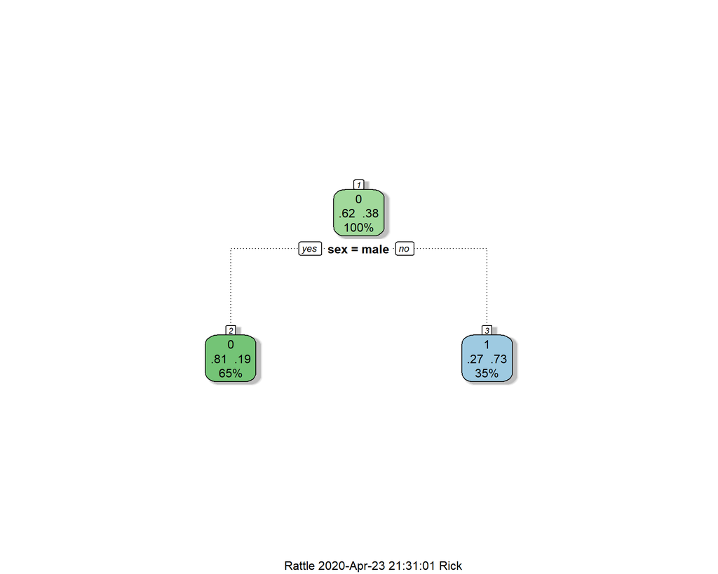

```r
fit_sex <- rpart(survived ~ sex, data = train_df, method = "class")
rattle::fancyRpartPlot(fit_sex)
```

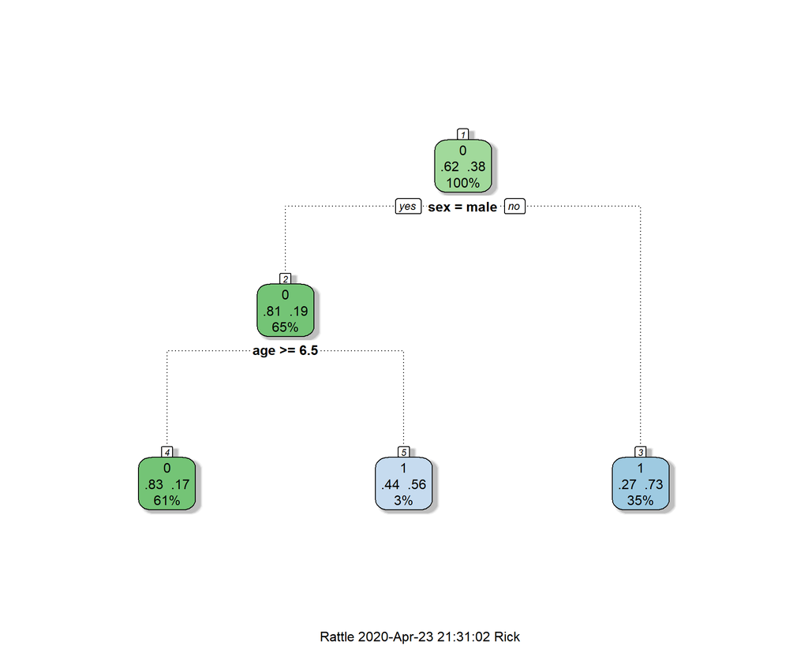

```r
fit_sex_age <- rpart(survived ~ sex + age, data = train_df, method = "class")
rattle::fancyRpartPlot(fit_sex_age)
```

If you a female, a 73% chance of survival. If male then if age is less than 6.5 your survival is 56%, otherwise its 17%.

Task: Confirm the above tree by calculating a proportional aggregation.

```r
train_sex_age_df <- train_df %>%
  select(survived, sex, age) %>%
  mutate(
    age_ge_6.5 = if_else(age >= 6.5, TRUE, FALSE),
    survived = as.integer(survived)
  )
glimpse(train_sex_age_df)
## Observations: 916
## Variables: 4
## $ survived   <int> 1, 1, 0, 1, 1, 0, 1, 0, 0, 1, 1, 0, 0, 1, 1, 1, 1, 0, 1,...
## $ sex        <fct> female, male, female, male, female, male, female, male, ...
## $ age        <dbl> 29.0000, 0.9167, 2.0000, 48.0000, 63.0000, 39.0000, 53.0...
## $ age_ge_6.5 <lgl> TRUE, FALSE, FALSE, TRUE, TRUE, TRUE, TRUE, TRUE, TRUE, ...
```

Perform the aggregation:

```r
aggregate(survived ~ sex + age_ge_6.5, data = train_sex_age_df, FUN = function(x){sum(x)/length(x)})
```

```
##      sex age_ge_6.5  survived
## 1 female      FALSE 0.6206897
## 2   male      FALSE 0.5625000
## 3 female       TRUE 0.7389831
## 4   male       TRUE 0.1696429
```

Again it appears that males with *age* less than 6.5 had a 56% chance of survival otherwise it is 17% as shown in `fit_sex_age` tree diagram.

## 3.3 Decision Tree with all variables

Task: Build the model with *pclass*, *sex*, *age*, *sibSp*, *parch*, *fare*, *embarked*, *title*, *family_size_dis*, *child*, *mother*, *fare_dis*.

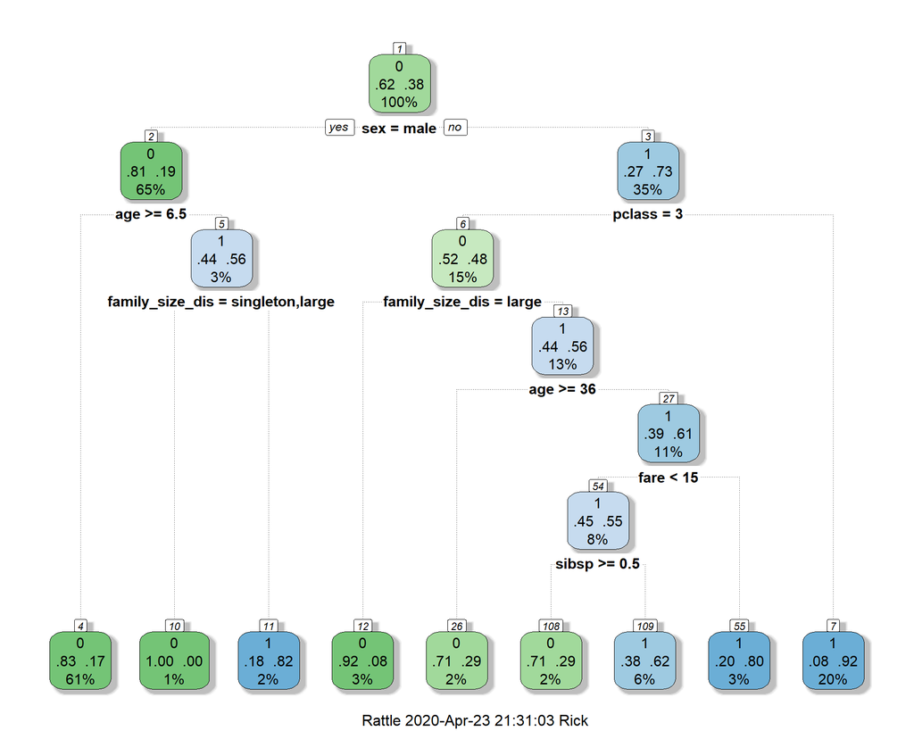

```r
fit_all <- rpart(survived ~ pclass + sex + age + sibsp + parch + fare + embarked + title + family_size_dis + child + mother + fare_dis, data = train_df, method = "class")
rattle::fancyRpartPlot(fit_all)
```

Task: Look at the split between *sex* and *pclass*.

```r
train_sex_pclass_eq_3_df <- train_df %>%
  select(survived, sex, pclass) %>%
  mutate(
    pclass_eq_3 = if_else(pclass == 3, TRUE, FALSE)
  )
glimpse(train_sex_pclass_eq_3_df)
## Observations: 916
## Variables: 4
## $ survived    <dbl> 1, 1, 0, 1, 1, 0, 1, 0, 0, 1, 1, 0, 0, 1, 1, 1, 1, 0, 1...
## $ sex         <fct> female, male, female, male, female, male, female, male,...
## $ pclass      <fct> 1, 1, 1, 1, 1, 1, 1, 1, 1, 1, 1, 1, 1, 1, 1, 1, 1, 1, 1...
## $ pclass_eq_3 <lgl> FALSE, FALSE, FALSE, FALSE, FALSE, FALSE, FALSE, FALSE,...
```

Task: Show the proportional aggregation of *survived* with *sex* and *pclass_eq_3*.

```r
aggregate(survived ~ sex + pclass_eq_3, data = train_sex_pclass_eq_3_df, FUN = function(x){sum(x)/length(x)})
```

```
##      sex pclass_eq_3  survived
## 1 female       FALSE 0.9180328
## 2   male       FALSE 0.2415254
## 3 female        TRUE 0.4822695
## 4   male        TRUE 0.1573034
```

It appears that females that have *pclass* = 3 have a 48% chance of survival. For females, that have *pclass* equal to 1 or 2, their survival is 92% as shown in the `fit_all` tree diagram.

Task: Attempt a simpler model by setting rpart.control(minsplit = 100 argument of rpart (i.e. the minimum number of observations in any terminal node).

[figure not shown]

```r
fit_all_100 <- rpart(survived ~ sex + pclass + age + sibsp + parch + embarked + title + family_size_dis + child + mother + fare_dis,
                 data = train_df,
                 method = "class",
                 control = rpart.control(minsplit = 100))
rattle::fancyRpartPlot(fit_all_100)
```

It appears that females in *pclass* = 3 who embarked from Southampton had a 38% chance of surviving, otherwise if not from Southampton, a 64% chance of survival.

Task: Build a simpler model with *sex*, *age*, and *pclass*.

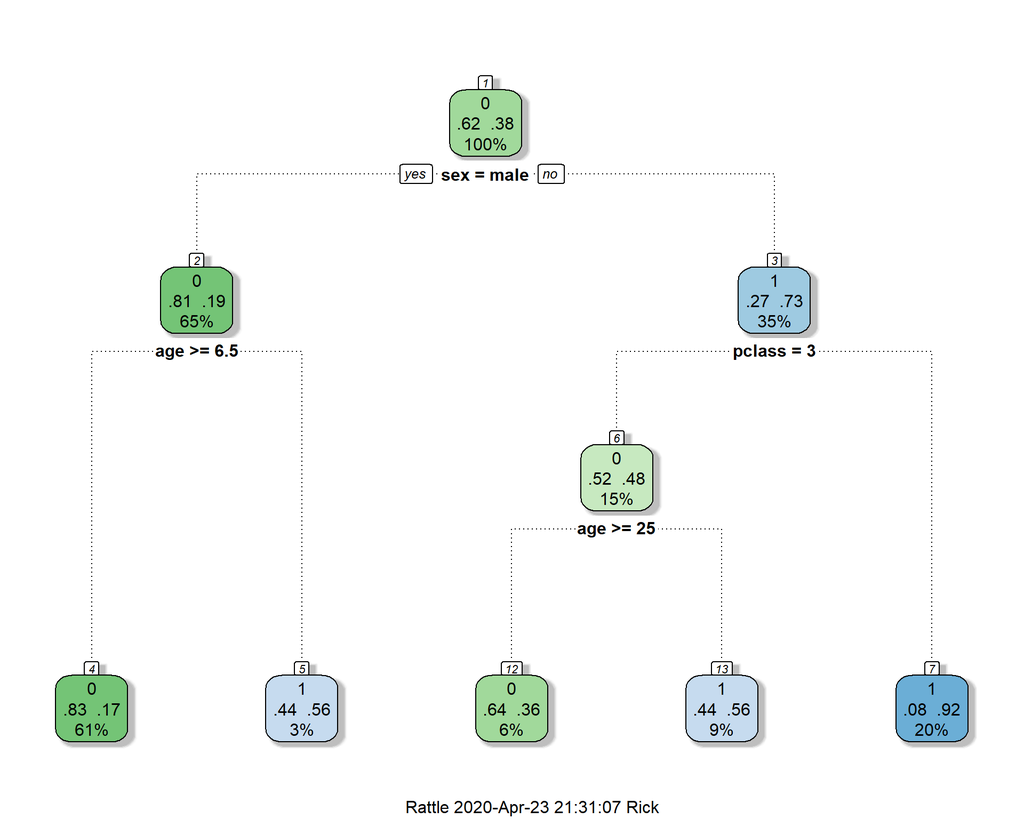

```r
fit_sex_age_pclass <- rpart(survived ~ sex + age + pclass,
                            data = train_df,
                            method = "class",
                            control = rpart.control(minsplit = 80))
rattle::fancyRpartPlot(fit_sex_age_pclass)
```

It appears that in addition to male survival at 56% if age is less than 6.5, we have for females in pclass equal to 3 and your age is less than 25 then your survival is 56%.

# 4 Model selection from many Decision Trees

Task: Build many Decision Trees via randomForest::randomForest() using all the variables.

```r
set.seed(754)
fit_all_rf <- randomForest::randomForest(factor(survived) ~ pclass + sex + age + sibsp + parch + fare + embarked + title + family_size_dis + child + mother + fare_dis, data = train_df, importance=TRUE)

fit_all_rf
```

```
##
## Call:
##  randomForest(formula = factor(survived) ~ pclass + sex + age +      sibsp + parch + fare + embarked + title + family_size_dis +      child + mother + fare_dis, data = train_df, importance = TRUE)
##                Type of random forest: classification
##                      Number of trees: 500
## No. of variables tried at each split: 3
##
##         OOB estimate of  error rate: 19%
## Confusion matrix:
##     0   1 class.error
## 0 507  60   0.1058201
## 1 114 235   0.3266476
```

Task: Look at what variables were important.

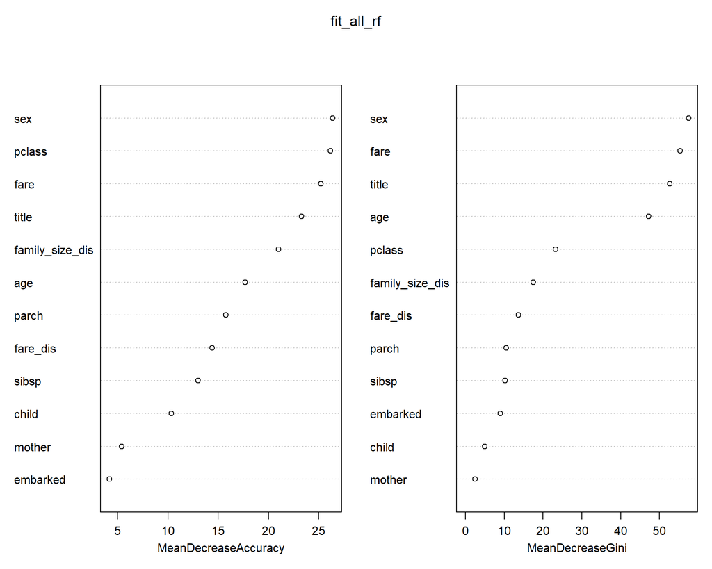

```r
randomForest::varImpPlot(fit_all_rf)
```

Task: Build a model from the top 4 variables of the MeanDecreaseGini plot using rpart().

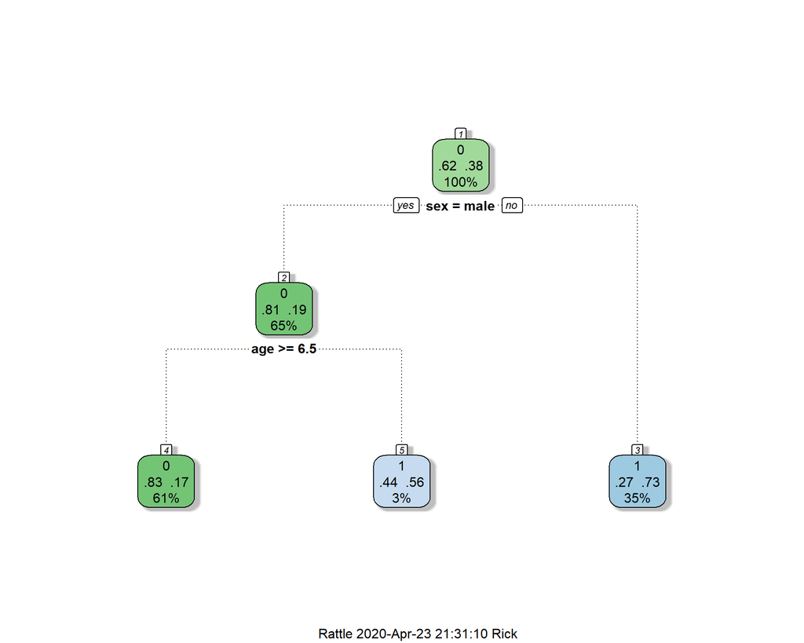

```r
fit_sex_title_fare_age <- rpart(survived ~ sex + fare + title + age,
                            data = train_df,
                            method = "class",
                            control = rpart.control(minsplit = 80))
rattle::fancyRpartPlot(fit_sex_title_fare_age)
```

Task: Compute randomForest() with just *sex* and *age*.

```r
set.seed(754)
fit_sex_age_rf <- randomForest::randomForest(factor(survived) ~ sex + age, data = train_df, importance=TRUE)
fit_sex_age_rf
```

```
##
## Call:
##  randomForest(formula = factor(survived) ~ sex + age, data = train_df,      importance = TRUE)
##                Type of random forest: classification
##                      Number of trees: 500
## No. of variables tried at each split: 1
##
##         OOB estimate of  error rate: 21.62%
## Confusion matrix:
##     0   1 class.error
## 0 476  91   0.1604938
## 1 107 242   0.3065903
```

Task: Show the error for `fit_sex_age_rf`.

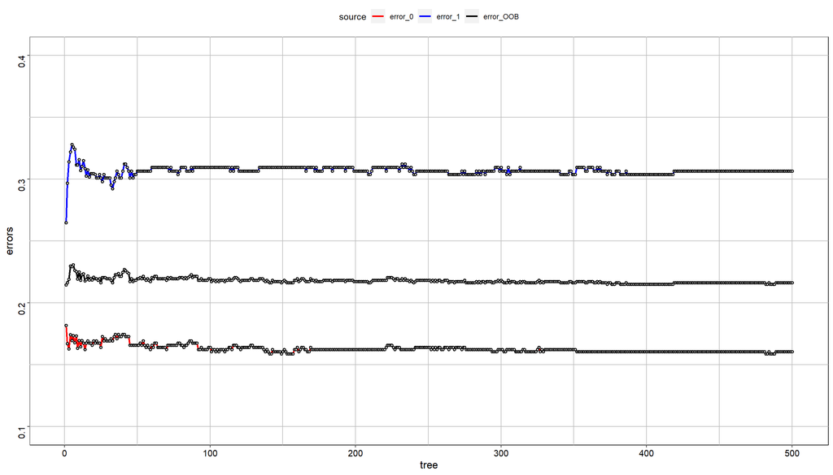

```r
plot_rf_df <- as.data.frame(fit_sex_age_rf$err.rate) %>%
  mutate(tree = seq(from = 1, to = 500, by = 1)) %>%
  rename(error_OOB = OOB) %>%
  rename(error_0 = `0`) %>%
  rename(error_1 = `1`)

 plot_rf_long_df <- pivot_longer(plot_rf_df, dplyr::starts_with("error"), names_to = "source", values_to = "errors")

RplotterPkg::create_scatter_plot(
  df = plot_rf_long_df,
  aes_x = "tree",
  aes_y = "errors",
  aes_color = "source",
  palette_colors = c("red", "blue", "black"),
  connect = TRUE,
  y_limits = c(0.10, 0.40)
)
```

# Prediction of Survived

Task: Predict using the `fit_sex_age_rf` model. Save the solution to a dataframe and to a file.

```r
predict_factor <- predict(fit_sex_age_rf, test_df)

results_df <- test_df %>%
  mutate(
    obs = survived,
    pred = predict_factor,
    score = if_else(survived == pred, 1, 0)
  ) %>%
  select(passenger_id, obs, pred, score)

results <- table(results_df$score)
results
```

```
##
##   0   1
##  88 305
```

```r
results_prop <- sum(results_df$score)/length(results_df$score)
results_prop
```

```
## [1] 0.7760814
```

Save the results.

```r
write_csv(results_df, path = "data/results_df.csv")
```